# Plant-pollintor networks worldwide are composed by the same specific building blocks

##Abstract

##INTRODUCTION

The interaction between plants and pollinators can be studied at different scales, from species level interactions (micro-scale) to the full network structure (macro-scale). Research of the plant-pollinator network structure have proven common invariant structural properties across them including a degree distribution that decays as a power law (Jordano 1987), nestedness (Bascompte et al. 2003), or modularity in large networks (Olesen et al. 2007). In addition, species phenological overlap, morphological matching and species abundances have been shown to be determinant for the understanding of pairwise plant-pollinator interactions (Bartomeus et al. 2016; Stang, Klinkhamer, and Van Der Meijden 2006; Peralta et al. 2020). However, both species level information and the holistic view of the full network involves missing relevant information for the understanding of ecological processes (Cirtwill et al. 2018; Simmons, Cirtwill, et al. 2019).

Traditionally, plant-pollinator research has focused on direct interactions and overlooked indirect interactions such as facilitative or competitive interactions between plants for pollinators (Moeller 2004; Sargent and Ackerly 2008). Despite the widespread nature of indirect interactions in ecological communities (Strauss 1991), plant-pollinator research often fails to finely capture those indirect interactions with the conventional analytical tools that condense the information either by species (e.g. interaction frequency) or in single topological indices (e.g. nestedness). Nonetheless, the emerging framework of network motifs in plant-pollinator research, the building blocks of a network that depict subsets of interactions (Milo et al. 2002), allows to consider both direct and indirect interactions (Simmons, Cirtwill, et al. 2019). The analysis of motifs (meso-scale) in plant-pollinator networks have revealed that the different ecological processes that govern species interactions (e.g., species abundances versus trait-matching) can lead to different patterns of indirect interactions (Simmons et al. 2020). However, the global patterns of indirect interactions in plant-pollinator networks (over- and under- representation of motifs) are still unknown.

Motifs are abstract representations often decoupled from species ecology. Hence, linking the structural properties of the meso-scale with the species ecology can help the understanding of ecological processes. For instance, different motifs can have different ecological meanings (Simmons, Cirtwill, et al. 2019) and the position within a motif can determine the species functional role (Stouffer et al. 2012; Baker et al. 2015). However, it is unclear how the species ecology and life history traits determines the species functional role within the network of interactions (Coux et al. 2016). For example, large pollinators can forage larger distances (Greenleaf et al. 2007), deposit greater pollen quantities (Földesi et al. 2021) and handle complex zygomorphic flowers in comparison with small pollinators that are restricted to lower floral complexity (Gong and Huang 2009). How this different pollinator behaviors translate into their interaction topology is unknown. Similarly, recent empirical findings indicate that the meso-scale is the best descriptor of plant reproductive success (Allen-Perkins et al. 2021), but little is known on how plants reproductive strategies shape their position within the network of interactions. Although some studies have evaluated plant reproductive strategies in plant-pollinator networks (Tur, Castro-Urgal, and Traveset 2013; Lázaro et al. 2020), they are often overlooked in a community context (Devaux, Lepers, and Porcher 2014) and rarely incorporated into plant-pollinator network studies. Hence, exploring how the main plant reproductive strategies integrate with the emergent motif framework can shed light on key aspects of ecosystem functioning.

Here, we used 60 plant-pollinator networks from 18 different studies and 14 countries, alongside a detailed grouping of plants into reproductive strategies and pollinator species into functional groups. Plants were grouped based on a comprehensive dataset that included floral, reproductive and vegetative traits compiled in Lanuza et al., (unpublished) on a larger set of plant-pollinator networks. Pollinators were grouped into the main taxonomical groups that differed in life form and behaviour. Then, we explored which motifs up to five nodes in these set of plant-pollinator networks were over and under-represented. Finally, we explored if the different plants and pollinators functional groups were over- or under-represented in certain positions.

##METHODS

**Plant-pollinator studies**

We have compiled 60 plant-pollinator networks from 18 different studies (Table S1). All studies sampled plant-pollinator interactions in natural systems and were selected based on wide geographical coverage and the presence of interaction frequency as a measure of interaction strength. In total, there were 503 plant species, 1,111 pollinator species and 6248 of pairwise interactions registered. For ease of data manipulation plant and pollinator species names were standardize with the help of the package taxize version 0.9.99 (Chamberlain et al. 2020).

**Plant and pollinator functional groups**

First, plant species were grouped into the optimal number of functional groups that summarized the main plant reproductive strategies. This was done with the help of hierarchical cluster analysis by using the trait dataset collated in Lanuza et al., (unpublished) that comprised 1,506 plant species and contained the same 60 plant-pollinator networks used in this study plus some non-weighted and weighted metawebs (see Table S1 Lanuza et al., unpublished). This dataset consisted on 8 floral, 4 reproductive and 3 vegetative traits (Table S2). We opted to calculate the plant functional groups on this larger set of species because of the higher accuracy when delimiting the functional groups with that many variables Dolnicar et al. (2014). For this, we calculated the distance of the different functional traits with the function gowdis from the package FD version 1.0-12 (Laliberté et al. 2014) with the method ward.D2 used for non-squared distances (Murtagh and Legendre 2014). All the numerical traits were previously scaled. Finally, we applied a hierarchical cluster analysis with the function hclust from the R stats package version 4.0.5 and calculated the optimal number of clusters with the function kgs from the package maptree version 1.4-7 (White and Gramacy 2009).

**Meso-scale analysis**

Following Simmons et al. (Simmons, Cirtwill, et al. 2019; Simmons et al. 2020), we broke down the plant-pollinator networks into their constituent motifs. Prior to analyses, we turned the quantitative networks into qualitative (or binary) ones, where interactions are present or absent.

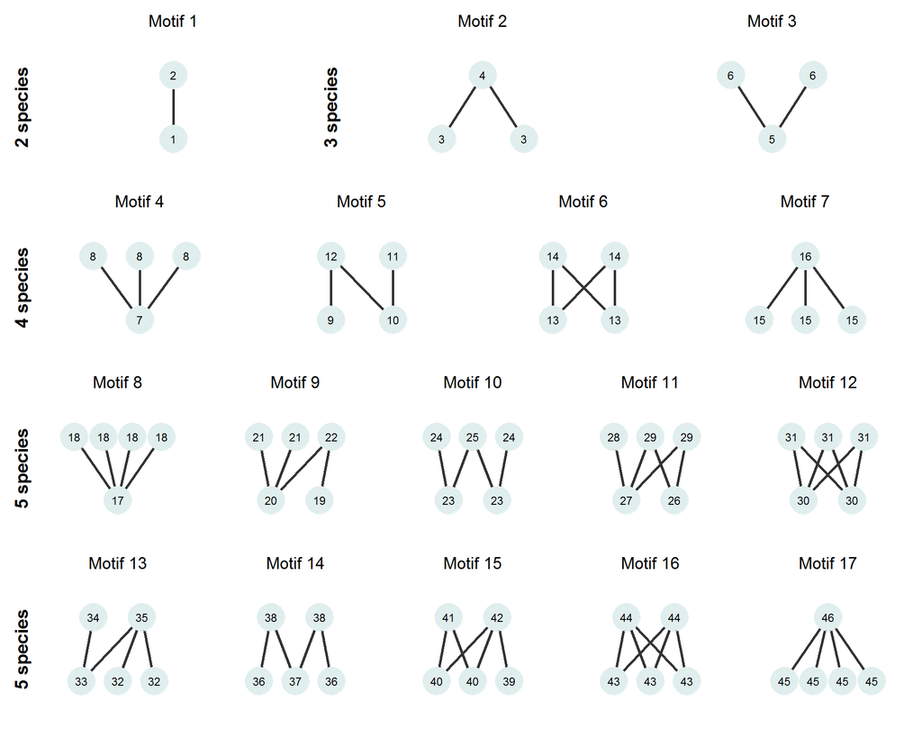

Figure 1. Adapted figure of Simmons et al., 2019 with all the possible motifs from two to five species in bipartite networks. There is a total of 17 possible motifs with 46 different positions denoted within each node.

To assess the significance of the observed frequencies, we created 1,000 simulated networks for each binary network using the ‘nullmodel’ function and the ‘vaznull’ model in the bipartite package (Dormann et al. 2009). Generated networks had the same number of plants and pollinators, as well as the same connectance of their corresponding empirical networks. After extracting the motif frequencies from the simulated networks, for each motif type and empirical network, we calculated the percentage of simulated networks whose frequencies were smaller than the ones observed, that is, we estimated the percentile of the observed motif frequencies. Motifs whose percentile is close to zero or 100 are under- or over-represented in the empirical networks, respectively, and, thus, they cannot be predicted by connectance and the number of species alone. To summarize general patterns across networks, we used an intercept-only linear mixed model (LMM) per motif, where the response variable was the observed motif percentile per network. In these models, we used the study identifiers in Table S1 as a random intercept. By doing so, we obtained estimates of the average motif frequency, in which we controlled the variation at the study level.

Next, we calculated which functional groups were over or under-represented in different motif positions by comparing position frequencies of empirical networks with those of their corresponding simulated counterparts. We extracted the position frequencies of all motifs from three to five nodes for each network and species by using the ‘bmotif’ package (Simmons, Sweering, et al. 2019). To estimate the position frequencies of each functional group in a given network, we added the frequencies of those species that belong to the group, and then, we normalised the resulting frequencies by dividing the position measure for each group by the total number of times that a group appears in any position within the same motif size class. Then, we calculated the percentile of the observed position frequencies for each group and network, just like we did motif frequencies. To outline the general patterns of position frequencies across networks and functional groups, we fit a LMM per motif position, where the response variable was the observed position percentile per network. We used the functional group identifier as an explanatory variable and the study identifiers as a random intercept. By adding the functional group estimates to the model intercept, we assessed the average motif frequency, after controlling the variation at the study level. Finally, we visualized with the help of the package ComplexHeatmap version 2.6.2 (Gu, Eils, and Schlesner 2016) over- and under- representation of plant and pollinator functional groups on the different motif positions.

Finally, we studied which motif combinations of functional groups (up to five nodes) are over or under-represented in 95% of our empirical networks (57 out of 60 arrangements, due to computational limitations to identify all the nodes in the motifs of the three networks with the highest number of links). To do so, for each of the 53,250 possible motif combinations, we estimated the observed and the expected probability of finding that combination in empirical networks, respectively. Then, we determined whether the observed probabilities are likely to come from the expected probabilities or not. To calculate the observed probability of a given combination $i$, $p_i^O$, we divided the number of times that $i$ appears in our set of empirical networks ($n_i^O$) by the sum of the number of times that each possible combination appeared: $p_i^O = n_i^O / \sum_{k=1}^{53,250} n_k^O$, and, consequently, $\sum_{k=1}^{53,250} p_k^O = 1$. To estimate the expected probability of a given motif combination $i$, $p_i^E$, firstly, we calculated the probability of finding a given functional group $x$ in the position $\alpha$ of $i$, $p_i(x,\alpha)$. Then, by assuming the independency of $p_i(x,\alpha)$, we computed the expected probability of the combination $i$ as the product of the probability of its pairs $(x,\alpha)$, that is, $p_i^E = \prod _{(x,\alpha )\in i} p_i(x,\alpha)$. To obtain $p_i(x,\alpha)$, we proceeded as follows. First, we calculated the number of times that the functional group $x$ appears in the position $\alpha$ in each empirical network $\eta$, denoted as $n_i^{\eta}(x,\alpha)$. Then, by controlling the variation at the network level, we assessed the average value of the absolute frequency of functional group $x$ appears in the position $\alpha$, $n_i(x,\alpha) = E\left [ n_i^{\eta}(x,\alpha) \right ]$, and estimated $p_i(x,\alpha)$ as $p_i(x,\alpha) = n_i(x,\alpha)/\sum_{k}n_i(k,\alpha)$. To obtain $n_i(x,\alpha)$, we fitted a LMM per motif position, where the response variable was the number of times that a given position was observed per network, the explanatory variable was functional group identifier, and the random intercept was given by network identifiers nested within the study identifiers. We used the ‘lmer’ package (Bates et al. 2015) to fit the LMMs models in our analyses.

Once we obtained $p_i^O$ and $p_i^E$, we used simulation to determine whether the former is likely to come from the latter or not, since the large number of possible motif combinations and the small probabilities for some of them advise against using an Exact test of goodness-of-fit or a Chi-square one. Specifically, we created 1,000 random samples with repetition of possible motif combinations, where each sample contained 10 million elements and, for each combination, the probability of being selected was equal to its expected probability. From those random samples, we extracted the mean and the standard deviation of the expected probability of $i$, denoted as $E\left [ p_i^E \right ]$ and $\sigma\left [ p_i^E \right ]$, respectively, and calculated the z-scores of $p_i^O$ as $z_i^O = \left ( p_i^O - E\left [ p_i^E \right ] \right )/\sigma \left [ p_i^E \right ]$, for those motif combinations with $p_i^O > 0$. According to the usual interpretation of z-scores, combinations with $z_i^O > 1.96$ are over-represented, whereas those with $z_i^O < -1.96$ are under-represented, at the 95% confidence level. Notice that we focused on combinations with $p_i^O > 10^{-7}$ because, beyond the interest that can arouse the combinations that appear at most once, we do not have enough numerical resolution to accurately detect whether or not those combinations are under-represented (due to the limited size of our random samples).

##RESULTS

**Functional groups**

The hierarchical cluster analysis divided the dataset with 1506 species and 15 traits into five different clusters with different and overlapping characteristics (Figure S1 and Figure S2). The subset of plant species used in this study (N = 503) were distributed evenly across these different larger five groups (see subset of species labels within cluster in Figure S1). The first cluster was dominated by herbs with hermaphrodite flowers with high levels of autonomous selfing and we we refer to this group as “selfing herbs”. The second cluster was characterized by small perennial species with a mixed of life forms (trees shrubs and herbs) with outcrossing hermaphroditic flowers and we refer to this group of species as “small outcrossing perennials”. The third cluster was dominated by also perennial species with a mixed of life forms too and had large self-incompatible hermaphroditic flowers with high number of ovules and we named this group “self-incompatible perennials with large flowers”. The fourth cluster had the tallest species, highest proportion of shrub and tree life forms, dioecious and monoecious breeding system with small flowers but the highest number of flowers per plant and inflorescence and we refer to this set of species as “tall plants with small unisexual flowers”. Finally, the last cluster of species was dominated by small perennial and shot-lived herbs with long self-compatible zygomorphic flowers unable to self-pollinate and we refer to this group as “short-lived outcrossers with long zygomorphic flowers”.

**Overall meso-scale patterns**

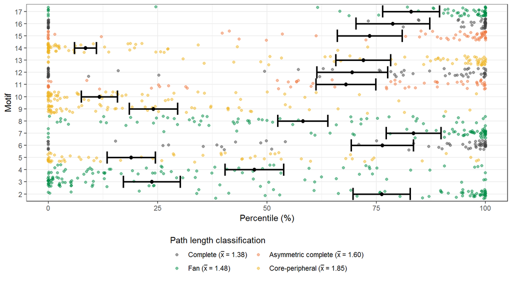

Figure 2. Comparison of the motif frequencies between empirical and simulated networks. Average percentages of motifs close to 0 and 100 indicate under- and over- representation in empirical networks. The different motifs are coloured by the mean path length as done in Simmons et al. (2020).

**Meso-scale functional groups position**

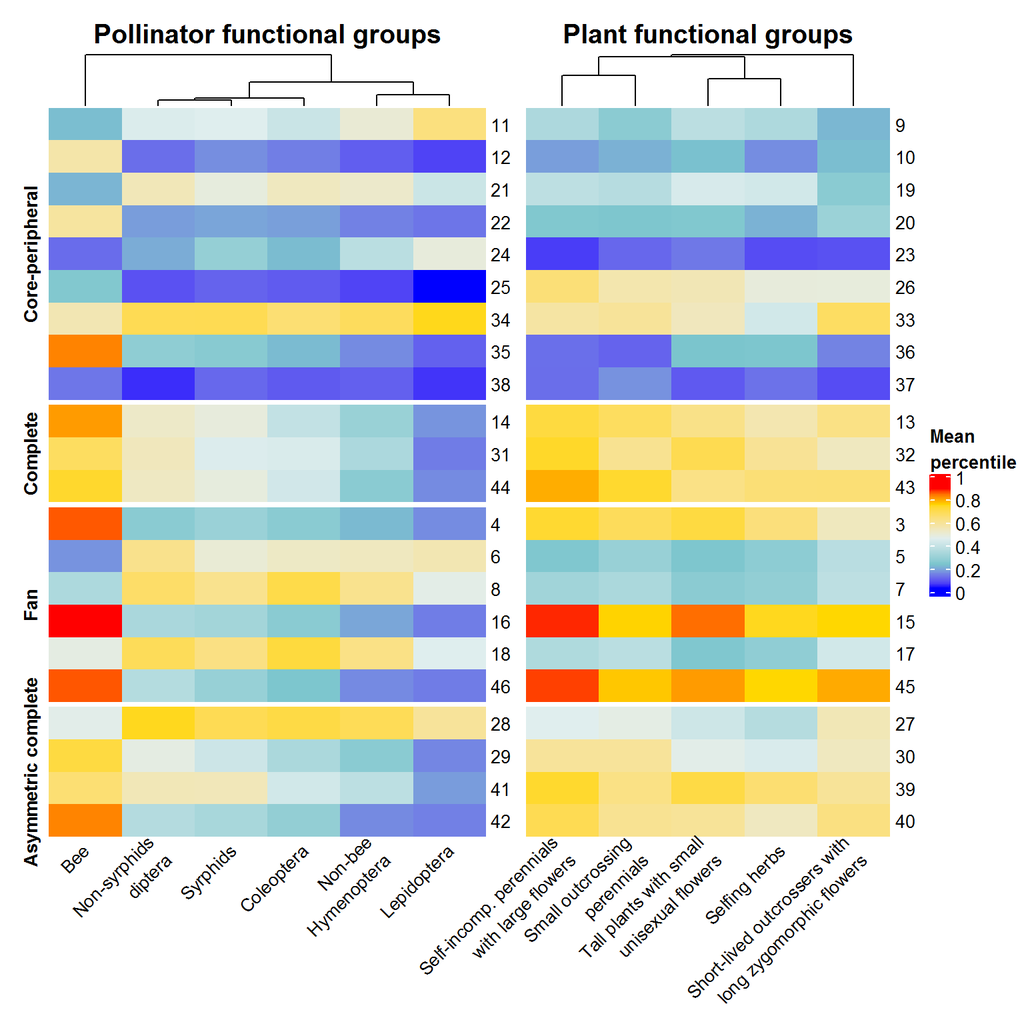

Figure 3. Heatmap indicating under- and over- representation of pollinator and plant functional groups in the different motif positions. The different motif positions are dividied by the average path length clasification by Simmons et al. (2020).

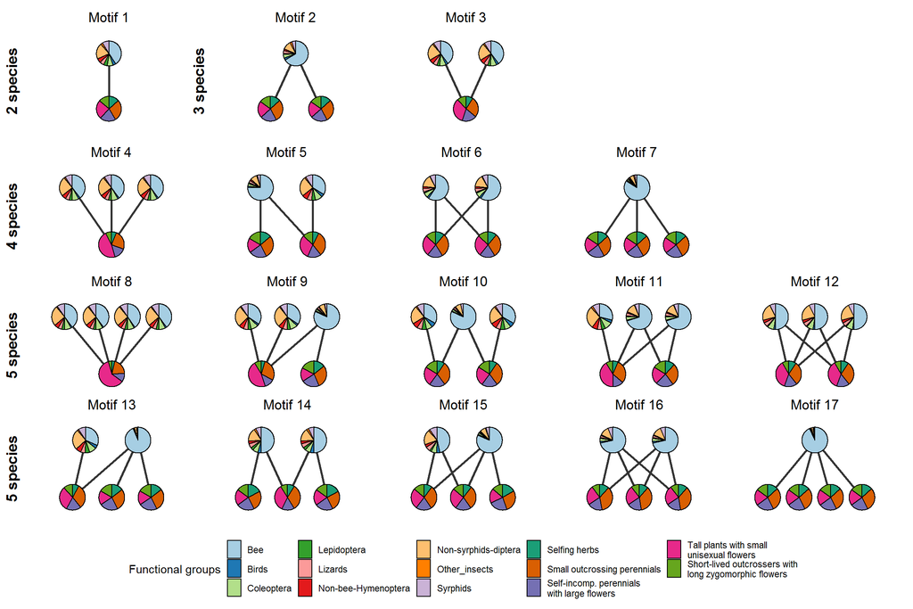

Figure 4. Graphical representation of the probability of finding a given functional group $x$ in the position $\alpha$ of motif $i$, $p_i(x,\alpha)$, for all the possible motifs from two to five species in bipartite networks. The slices in the nodes for a given functional group $x$ are proportional to the corresponding value of $p_i(x,\alpha)$.

##REFERENCES

Allen-Perkins, Alfonso, Maria Hurtado, David Garcia-Callejas, Oscar Godoy, and Ignasi Bartomeus. 2021. “Community Level Individual-Based Plant-Pollinator Networks Unveil Pollen Flow Dynamics and Plant Reproductive Success.” *bioRxiv*.

Baker, Nick J, Riikka Kaartinen, Tomas Roslin, and Daniel B Stouffer. 2015. “Species’ Roles in Food Webs Show Fidelity Across a Highly Variable Oak Forest.” *Ecography* 38 (2): 130–39.

Bartomeus, Ignasi, Dominique Gravel, Jason M Tylianakis, Marcelo A Aizen, Ian A Dickie, and Maud Bernard-Verdier. 2016. “A Common Framework for Identifying Linkage Rules Across Different Types of Interactions.” *Functional Ecology* 30 (12): 1894–1903.

Bascompte, Jordi, Pedro Jordano, Carlos J Melián, and Jens M Olesen. 2003. “The Nested Assembly of Plant–Animal Mutualistic Networks.” *Proceedings of the National Academy of Sciences* 100 (16): 9383–7.

Bates, Douglas, Martin Mächler, Ben Bolker, and Steve Walker. 2015. “Fitting Linear Mixed-Effects Models Using lme4.” *Journal of Statistical Software* 67 (1): 1–48. https://doi.org/10.18637/jss.v067.i01.

Chamberlain, Scott, Eduard Szoecs, Zachary Foster, Zebulun Arendsee, Carl Boettiger, Karthik Ram, Ignasi Bartomeus, et al. 2020. *Taxize: Taxonomic Information from Around the Web*.

Cirtwill, Alyssa R, Tomas Roslin, Claus Rasmussen, Jens Mogens Olesen, and Daniel B Stouffer. 2018. “Between-Year Changes in Community Composition Shape Species’ Roles in an Arctic Plant–Pollinator Network.” *Oikos* 127 (8): 1163–76.

Coux, Camille, Romina Rader, Ignasi Bartomeus, and Jason M Tylianakis. 2016. “Linking Species Functional Roles to Their Network Roles.” *Ecology Letters* 19 (7): 762–70.

Devaux, Celine, Clotilde Lepers, and Emmanuelle Porcher. 2014. “Constraints Imposed by Pollinator Behaviour on the Ecology and Evolution of Plant Mating Systems.” *Journal of Evolutionary Biology* 27 (7): 1413–30.

Dolnicar, Sara, Bettina Grün, Friedrich Leisch, and Kathrin Schmidt. 2014. “Required Sample Sizes for Data-Driven Market Segmentation Analyses in Tourism.” *Journal of Travel Research* 53 (3): 296–306.

Dormann, C. F., J. Frueund, N. Bluethgen, and B. Gruber. 2009. “Indices, Graphs and Null Models: Analyzing Bipartite Ecological Networks.” *The Open Ecology Journal* 2: 7–24.

Földesi, Rita, Brad G Howlett, Ingo Grass, and Péter Batáry. 2021. “Larger Pollinators Deposit More Pollen on Stigmas Across Multiple Plant Species—a Meta-Analysis.” *Journal of Applied Ecology* 58 (4): 699–707.

Gong, Yan-Bing, and Shuang-Quan Huang. 2009. “Floral Symmetry: Pollinator-Mediated Stabilizing Selection on Flower Size in Bilateral Species.” *Proceedings of the Royal Society B: Biological Sciences* 276 (1675): 4013–20.

Greenleaf, Sarah S, Neal M Williams, Rachael Winfree, and Claire Kremen. 2007. “Bee Foraging Ranges and Their Relationship to Body Size.” *Oecologia* 153 (3): 589–96.

Gu, Zuguang, Roland Eils, and Matthias Schlesner. 2016. “Complex Heatmaps Reveal Patterns and Correlations in Multidimensional Genomic Data.” *Bioinformatics* 32 (18): 2847–9.

Jordano, Pedro. 1987. “Patterns of Mutualistic Interactions in Pollination and Seed Dispersal: Connectance, Dependence Asymmetries, and Coevolution.” *The American Naturalist* 129 (5): 657–77.

Laliberté, Etienne, Pierre Legendre, Bill Shipley, and Maintainer Etienne Laliberté. 2014. “Package ‘Fd’.” *Measuring Functional Diversity from Multiple Traits, and Other Tools for Functional Ecology*.

Lázaro, Amparo, Carmelo Gómez-Martı́nez, David Alomar, Miguel A González-Estévez, and Anna Traveset. 2020. “Linking Species-Level Network Metrics to Flower Traits and Plant Fitness.” *Journal of Ecology* 108 (4): 1287–98.

Milo, Ron, Shai Shen-Orr, Shalev Itzkovitz, Nadav Kashtan, Dmitri Chklovskii, and Uri Alon. 2002. “Network Motifs: Simple Building Blocks of Complex Networks.” *Science* 298 (5594): 824–27.

Moeller, David A. 2004. “Facilitative Interactions Among Plants via Shared Pollinators.” *Ecology* 85 (12): 3289–3301.

Murtagh, Fionn, and Pierre Legendre. 2014. “Ward’s Hierarchical Agglomerative Clustering Method: Which Algorithms Implement Ward’s Criterion?” *Journal of Classification* 31 (3): 274–95.

Olesen, Jens M, Jordi Bascompte, Yoko L Dupont, and Pedro Jordano. 2007. “The Modularity of Pollination Networks.” *Proceedings of the National Academy of Sciences* 104 (50): 19891–6.

Peralta, Guadalupe, Diego P Vázquez, Natacha P Chacoff, Silvia B Lomáscolo, George LW Perry, and Jason M Tylianakis. 2020. “Trait Matching and Phenological Overlap Increase the Spatio-Temporal Stability and Functionality of Plant–Pollinator Interactions.” *Ecology Letters* 23 (7): 1107–16.

Sargent, Risa D, and David D Ackerly. 2008. “Plant–Pollinator Interactions and the Assembly of Plant Communities.” *Trends in Ecology & Evolution* 23 (3): 123–30.

Simmons, Benno I, Andrew P Beckerman, Katrine Hansen, Pietro K Maruyama, Constantinos Televantos, Jeferson Vizentin-Bugoni, and Bo Dalsgaard. 2020. “Niche and Neutral Processes Leave Distinct Structural Imprints on Indirect Interactions in Mutualistic Networks.” *Functional Ecology*.

Simmons, Benno I, Alyssa R Cirtwill, Nick J Baker, Hannah S Wauchope, Lynn V Dicks, Daniel B Stouffer, and William J Sutherland. 2019. “Motifs in Bipartite Ecological Networks: Uncovering Indirect Interactions.” *Oikos* 128 (2): 154–70.

Simmons, Benno I, Michelle JM Sweering, Maybritt Schillinger, Lynn V Dicks, William J Sutherland, and Riccardo Di Clemente. 2019. “Bmotif: A Package for Motif Analyses of Bipartite Networks.” *Methods in Ecology and Evolution* 10 (5): 695–701.

Stang, Martina, Peter GL Klinkhamer, and Eddy Van Der Meijden. 2006. “Size Constraints and Flower Abundance Determine the Number of Interactions in a Plant–Flower Visitor Web.” *Oikos* 112 (1): 111–21.

Stouffer, Daniel B, Marta Sales-Pardo, M Irmak Sirer, and Jordi Bascompte. 2012. “Evolutionary Conservation of Species’ Roles in Food Webs.” *Science* 335 (6075): 1489–92.

Strauss, Sharon Y. 1991. “Indirect Effects in Community Ecology: Their Definition, Study and Importance.” *Trends in Ecology & Evolution* 6 (7): 206–10.

Tur, Cristina, Rocı́o Castro-Urgal, and Anna Traveset. 2013. “Linking Plant Specialization to Dependence in Interactions for Seed Set in Pollination Networks.” *PloS One* 8 (10): e78294.

White, D, and RB Gramacy. 2009. “Maptree: Mapping, Pruning, and Graphing Tree Models. R Package Version 1.4-5.”

##SUPPLEMENTARY MATERIAL

**TABLES**

Table S1. List of studies ordered by author with the year of publication, number of contributed networks and digital object identifier

| First author | Year | Number of networks | Country | DOI |
| --- | --- | --- | --- | --- |
| Arroyo-Correa | 2019 | 3 | New Zealand | https://doi.org/10.1111/1365-2745.13332 |
| Bartomeus | 2008 | 6 | Spain | https://doi.org/10.1007/s00442-007-0946-1 |
| Bartomeus | 2015 | 16 | Spain | https://github.com/ibartomeus/BeeFunData |
| Bundgaard | 2003 | 1 | Denmark | Unpublished, Master thesis |
| Burkle | 2013 | 1 | United States | https://doi.org/10.1126/science.1232728 |
| Dicks | 2002 | 2 | England | https://doi.org/10.1046/j.0021-8790.2001.00572.x |
| Dupont | 2003 | 3 | Denmark | https://doi.org/10.1111/j.1365-2656.2008.01501.x |
| Elberling | 1999 | 1 | Sweden | https://doi.org/10.1111/j.1600-0587.1999.tb00507.x |
| Fang | 2008 | 1 | China | https://doi.org/10.1111/1749-4877.12190 |
| Inouye | 1988 | 1 | United States | https://doi.org/10.1111/j.1442-9993.1988.tb00968.x |
| Kaiser-Bunbury | 2017 | 8 | Seychelles | https://doi.org/10.1038/nature21071 |
| Kaiser-Bunbury | 2011 | 6 | Seychelles | https://doi.org/10.1111/j.1365-2745.2010.01732.x |
| Kaiser-Bunbury | 2010 | 2 | Mauritius | https://doi.org/10.1016/j.ppees.2009.04.001 |
| Lundgren | 2005 | 1 | Denmark (Greenland) | https://doi.org/10.1657/1523-0430(2005)037[0514:TDAHCW]2.0.CO;2 |
| Olesen | 2002 | 2 | Mauritius and Portugal (Azores) | https://doi.org/10.1046/j.1472-4642.2002.00148.x |
| Peralta | 2006 | 4 | Argentina | https://doi.org/10.1111/ele.13510 |
| Small | 1976 | 1 | Japan | /13960/t4km08d21 |
| Souza | 2017 | 1 | Brazil | https://doi.org/10.1111/1365-2745.12978 |

Table S2. Traits used to delimit the different plant functional groups divided in quantitative and categorical traits.

| Quantitative traits Type | Quantitative traits Traits | Categorical traits Type | Categorical traits Traits |
| --- | --- | --- | --- |
| Vegetative | Plant height (m) | Vegetative | Lifepan |
| Floral | Flower width (mm) | Vegetative | Life form |
| Floral | Flower length (mm) | Floral | Flower shape |
| Floral | Inflorescence width (mm) | Floral | Flower symmetry |
| Floral | Style length (mm) | Reproductive | Autonomous selfing |
| Floral | Ovules per flower | Reproductive | Compatibility system |
| Floral | Flowers per plant | Reproductive | Breeding system |
| Reproductive | Autonomous selfing (fruit set) |  |  |

**FIGURES**

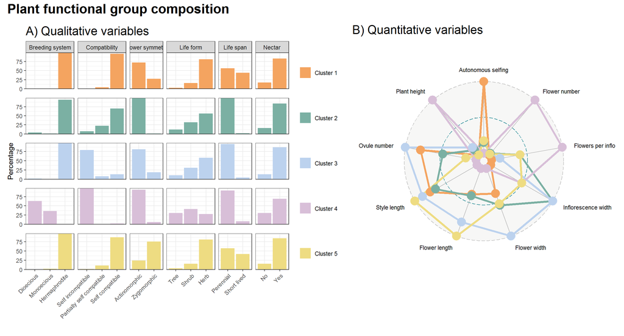

Figure S1. Plant functional group composition separated in qualitative and quantitative variables. Panel A) shows the percentage of the different categories within trait represented with different colours for each functional group. Plot B) shows the radar plot of the different quantitative variables standardize on the same scale also coloured with the same patterns of colours as qualitative variables per cluster.

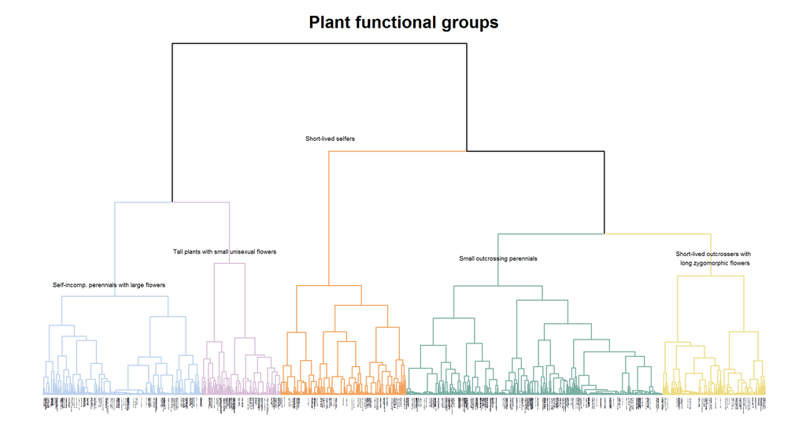

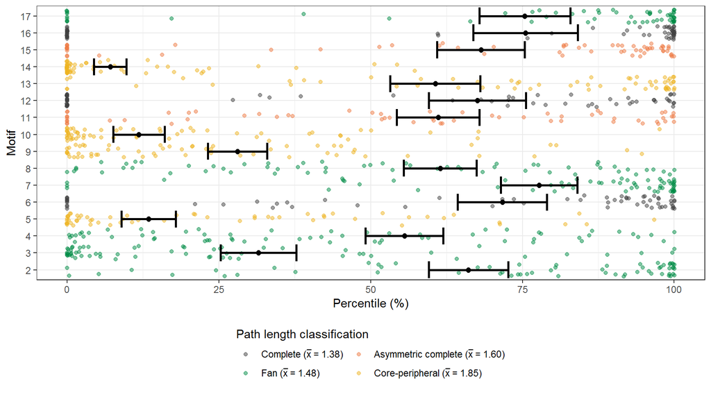

Figure S3. Comparison of the motif frequencies between empirical and simulated networks. Average percentages of motifs close to 0 and 100 indicate under- and over- representation in empirical networks, after removing non-robust links, that is, interactions whose frequency was equal to one. The different motifs are coloured by the mean path length as done in Simmons et al. (2020).

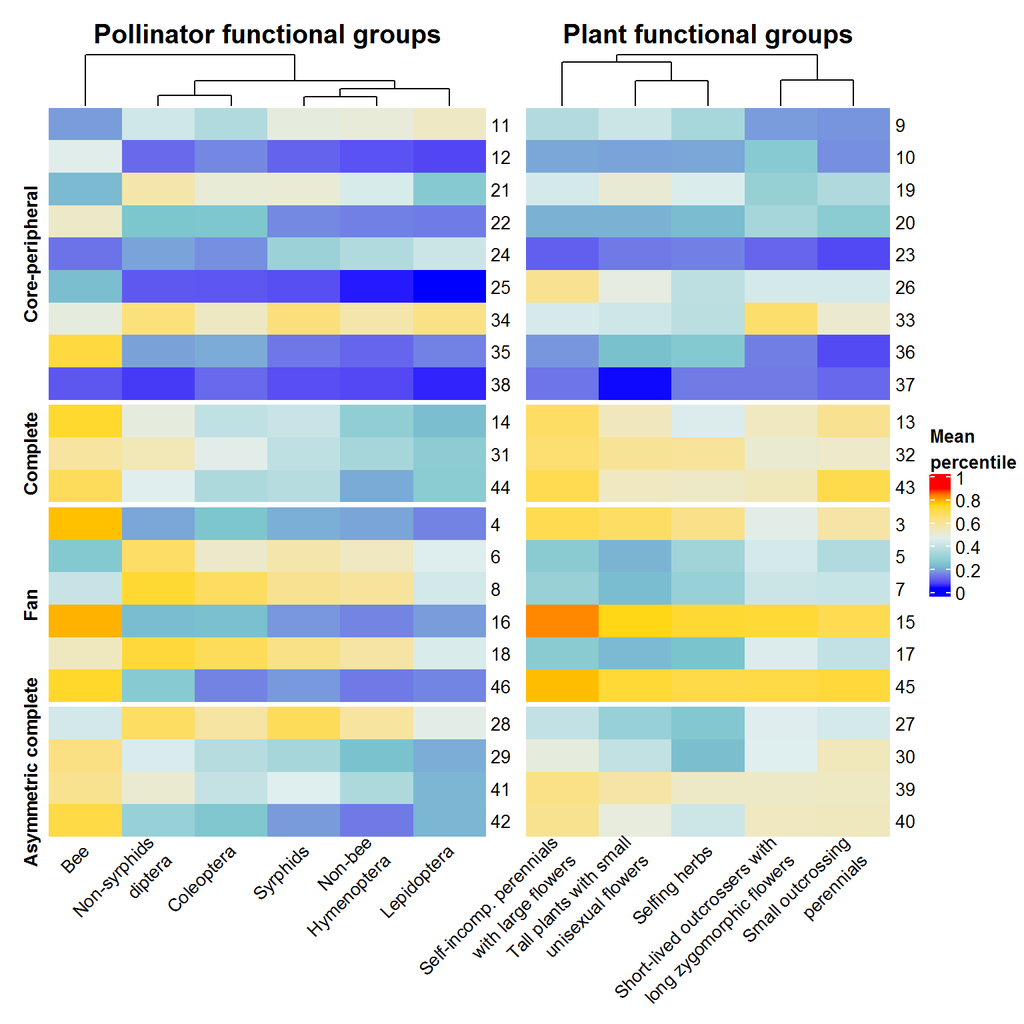

Figure S4. Heatmap indicating under- and over- representation of pollinator and plant functional groups in the different motif positions, after removing non-robust links, that is, interactions whose frequency was equal to one. The different motif positions are dividied by the average path length clasification by Simmons et al. (2020).